# Tracking the ARF Condensate Movement

Yaning Yuan

2022-11-04

# Background

Membraneless biocondensates formed by liquid-liquid separation of transcription factors have been shown to move along cytoskeleton in *Arabidopsis*. Here, I quantified the movement of biocondensate formed by an auxin response factor. The rate of movement was represented by the velocity, and the direction of movement was represented by the change of angle in between two steps. I am interested to see if the condensate show any **fast and directed** movement patterns, which indicates moving along a cytoskeletal structure.

```r
library(dplyr)
library(openxlsx)
library(ggplot2)
library(viridis)
library(ggpointdensity)
```

## Import data and take a glimpse

The dataset contains three columns, which are the Cell ID, the velocity, and the angle. There are 79194 lines, which means during the moving, 79194 spots were recorded in this document.

```r
data<-read.xlsx("ARF19_data.xlsx")
glimpse(data)
```

```
## Rows: 79,194
## Columns: 3
## $ Cell              <chr> "pARF19-ARF19 01-21-22 individule 6 cell2", "pARF19-…
## $ `velocity.µm/sec` <dbl> 0.7776443, 0.8032984, 0.5858528, 0.8993309, 0.719945…
## $ angle.º           <dbl> 10.784861, 25.983321, 103.191307, 114.818230, 109.55…
```

## How does the distribution look like?

Now I want to first take a look at the **overall distribution** of spots. We can see that although most of the movements are either slow or undirected, there are some spots that show fast and directed moving pattern.

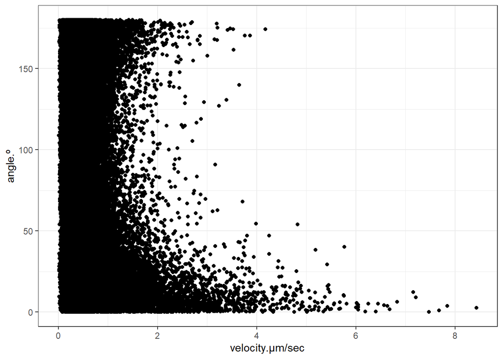

```r
ggplot(data, aes(x=`velocity.µm/sec`, y=angle.º))+
  geom_point()+
  theme_bw()
```

## Is the distribution consistent across all cells?

Taking a closer look at each cell, we can see that most of the cells follow the same distribution.

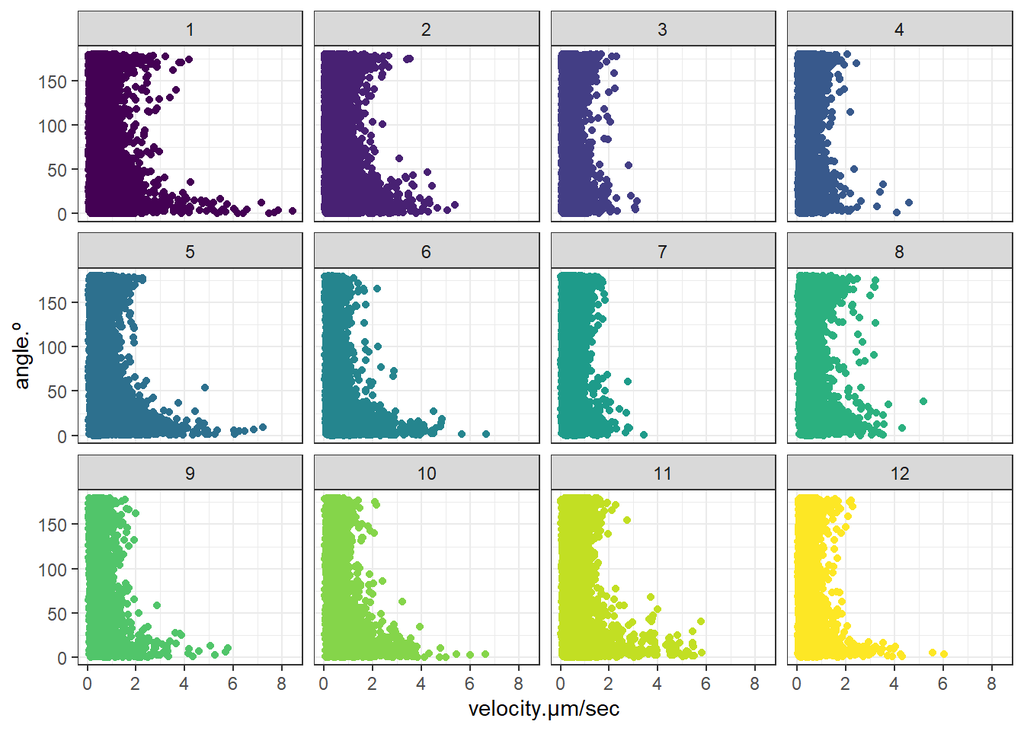

```r
tmp<-data%>%
  group_by(Cell)%>%
  mutate(cell_id=group_indices())
ggplot(tmp, aes(x=`velocity.µm/sec`, y=angle.º , color = Cell))+
  geom_point()+
  scale_colour_viridis_d()+
  facet_wrap(~cell_id)+
  theme_bw()+
  theme(legend.position = "none")
```

## How does the distribution actually look like?

To answer **how many spots move in a fast and directed way**, I want to see how many spots are actually represented in a small area. To achieve this, I colored the plot by the density of spots. We can see that while the majority of spots have speed lower than 0.5 um/s, there are a small group that move with **high velocity and small angle**. These spots could be moving along the cytoskeletal structures.

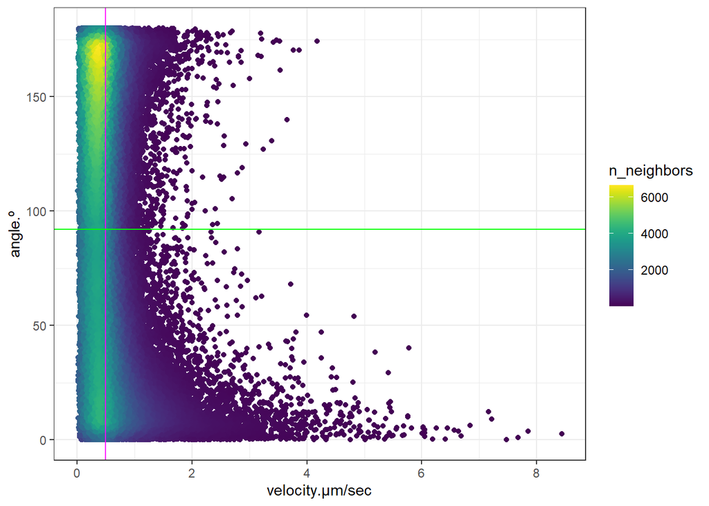

```r
ggplot(data, aes(x=`velocity.µm/sec`, y=angle.º))+
  geom_pointdensity()+
  geom_vline(xintercept=mean(data$`velocity.µm/sec`, na.rm = TRUE), color = "magenta")+
  geom_hline(yintercept=mean(data$angle.º , na.rm = TRUE), color = "green")+
  scale_color_viridis()+
  theme_bw()
```